# Morphological Transformations

Morphologicla Transformation은 이미지를 Segmentation하여 단순화, 제거, 보정을 통해서 형태를 파악하는 목적으로 사용이 됩니다.  
일반적으로 binary나 grayscale image에 사용이 됩니다.  
사용하는 방법으로는 Dilation(팽창), Erosion(침식), 그리고 2개를 조합한 Opening과 Closing이 있습니다.  
여기에는 2가지 Input값이 있는데, 하나는 원본 이미지이고 또 다른 하나는 structuring element입니다.  
Morphologicla Transformationは、イメージをSegmentationして単純化、除去、補正を通して形態を把握する目的で使用されます。  
一般的にbinaryやgrayscale imageに使用されます。  
使う方法としてはDilation（膨張）、Erosion（侵食）、そして2つを組み合わせたOpeningとClosingがあります。  
ここには2つのInput値がありますが、1つはオリジナルの画像で、もう1つはstructuringelementです。

## Erosion

각 Pixel에 structuring element를 적용하여 하나라도 0이 있으면 대상 pixel을 제거하는 방법입니다.  
원본의 각 pixel에 적용을 하여 겹치는 부분이 없는 부분이 하나라도 있으면 그 중심 pixel을 제거하는 방식입니다.  
이 방법은 작은 Object를 제거하는 효과가 있습니다.

各Pixelにstructuring elementを適用し、1つでも0があれば対象のpixelを除去する方法です。  
原本の各pixelに適用して重なる部分がない部分が一つでもあれば、その中心pixelを除去する方式です。  
この方法は小さなObjectを取り除く効果を持ちます。

cv2.erode(src, kernel, dst, anchor, iterations, borderType, borderValue)

src – the depth should be one of CV_8U, CV_16U, CV_16S, CV_32F or CV_64F.  
kernel – structuring element. cv2.getStructuringElemet() 関数でつく作られる（？）  
anchor – structuring elementの中心. default (-1,-1)で中心点.  
iterations – erosion 適用の繰り返すの数

#### depth(Data Type)

CV_8U : 8-bit unsigned integer: uchar ( 0..255 )  
CV_8S : 8-bit signed integer: schar ( -128..127 )  
CV_16U : 16-bit unsigned integer: ushort ( 0..65535 )  
CV_16S : 16-bit signed integer: short ( -32768..32767 )  
CV_32S : 32-bit signed integer: int ( -2147483648..2147483647 )  
CV_32F : 32-bit floating-point number: float ( -FLT_MAX..FLT_MAX, INF, NAN )  
CV_64F : 64-bit floating-point number: double ( -DBL_MAX..DBL_MAX, INF, NAN )

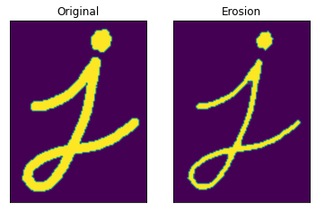

```python
import cv2
import numpy as np
from matplotlib import pyplot as plt


img = cv2.imread('j.jpg',0)
kernel = np.ones((5,5),np.uint8)
erosion = cv2.erode(img,kernel,iterations = 3) # <- 1にしてみてあまり差がなかった。

plt.subplot(1,2,1),plt.imshow(img),plt.title("Original")
plt.xticks([]),plt.yticks([])
plt.subplot(1,2,2),plt.imshow(erosion),plt.title("Erosion")
plt.xticks([]),plt.yticks([])
plt.show()
```

## Dilation

Erosion과 반대로 대상을 확장한 후 작은 구멍을 채우는 방법입니다.  
Erosion과 마찬가지로 각 pixel에 structuring element를 적용합니다.  
대상 pixel에 대해서 OR 연산을 수행합니다. 즉 겹치는 부분이 하나라도 있으면 이미지를 확장합니다.  
Erosionとは逆に対象を拡張した後に小さな穴を埋める方法です。  
Erosionと同じく各pixelにstructuring elementを適用します。  
対象pixel に対してOR 演算を行います。  
つまり、重なる部分がひとつでもあれば、イメージを拡張します。

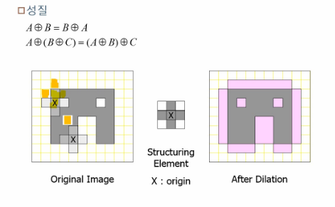

위 그림은 십자형 structuring element를 원본이미지에 OR 연산을 적용합니다.  
최종적으로 확장된 이미지를 얻을 수 있습니다. 결과적으로 경계가 부드러워 지고, 구멍이 메꿔지는 효과를 얻을 수 있습니다.  
上図は、十字型structuring elementをオリジナルの画像にOR演算を適用します。  
最終的に拡張されたイメージを得られます。  
結果的に、境界が柔らかくなり、穴がふさがる効果が得られます。

src – the depth should be one of CV_8U, CV_16U, CV_16S, CV_32F or CV_64F.  
kernel – structuring element. cv2.getStructuringElemet() 関数でつく作られる  
anchor – structuring elementの中心. default (-1,-1)で中心点.  
iterations – 適用の繰り返すの数

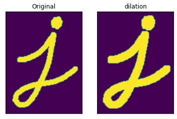

```python
import cv2
import numpy as np
from matplotlib import pyplot as plt


img = cv2.imread('j.jpg',0)
kernel = np.ones((5,5),np.uint8)
dilation = cv2.dilate(img,kernel,iterations = 3)# <- 1にしてみてあまり差がなかった。

plt.subplot(1,2,1),plt.imshow(img),plt.title("Original")
plt.xticks([]),plt.yticks([])
plt.subplot(1,2,2),plt.imshow(dilation),plt.title("dilation")
plt.xticks([]),plt.yticks([])
plt.show()
```

## Opening and Closing

OpeningとClosingは、ErosionとDilationの組み合わせの結果です。 差はあるものを先に適用する差です。

Opeing : Erosion適用後、Dilation適用。小さなObjectや突起除去に適合  
Closing : Dilation適用後のErosion適用。全体的な輪郭把握に適合

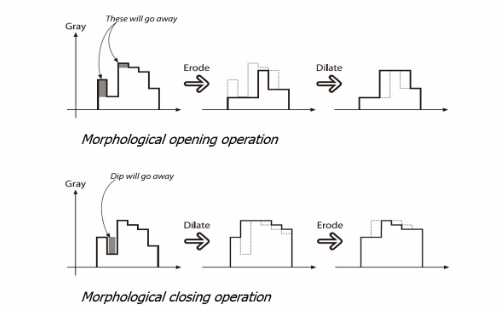

cv2.morphologyEx(src, op, kernel[, dst[, anchor[, iterations[, borderType[, borderValue]]]]]) → dst

src – Source image. The number of channels can be arbitrary. The depth should be one of CV_8U, CV_16U, CV_16S, CV_32F or CV_64F

op – Type of a morphological operation that can be one of the following:

MORPH_OPEN - an opening operation  
MORPH_CLOSE - a closing operation  
MORPH_GRADIENT - a morphological gradient. Dilationとerosionの差.  
MORPH_TOPHAT - “top hat”. OpeiningとOriginalの差  
MORPH_BLACKHAT - “black hat”. ClosingとOriginalの差

kernel – structuring element. cv2.getStructuringElemet() 関数でつく作られる.  
anchor – structuring elementの中心. default (-1,-1)で中心点.  
iterations – erosion and dilation 適用の繰り返すの数  
borderType – Pixel extrapolation method. See borderInterpolate for details.  
borderValue – Border value in case of a constant border. The default value has a special meaning.

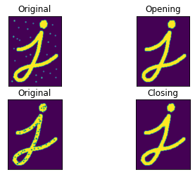

```python
import cv2
import numpy as np
from matplotlib import pyplot as plt


img2 = cv2.imread('j2.jpg',0)
img3 = cv2.imread('j3.jpg',0)
kernel = np.ones((5,5),np.uint8)

opening = cv2.morphologyEx(img2, cv2.MORPH_OPEN, kernel, iterations = 3)
closing = cv2.morphologyEx(img3, cv2.MORPH_CLOSE, kernel, iterations = 3)


images =[img2, opening, img3, closing]
titles =['Original', 'Opening', 'Original','Closing']

for i in range(4):
    plt.subplot(2,2,i+1),plt.imshow(images[i]),plt.title(titles[i])
    plt.xticks([]),plt.yticks([])
plt.show()
```

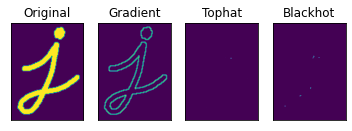

```python
import cv2
import numpy as np
from matplotlib import pyplot as plt


img = cv2.imread('j.jpg',0)
kernel = np.ones((5,5),np.uint8)

gradient = cv2.morphologyEx(img, cv2.MORPH_GRADIENT, kernel)##iterationsは省略
tophat = cv2.morphologyEx(img, cv2.MORPH_TOPHAT, kernel)
blackhat = cv2.morphologyEx(img, cv2.MORPH_BLACKHAT, kernel)

images =[img, gradient, tophat, blackhat]
titles =['Original', 'Gradient', 'Tophat','Blackhot']

for i in range(4):
    plt.subplot(1,4,i+1),plt.imshow(images[i]),plt.title(titles[i])
    plt.xticks([]),plt.yticks([])
plt.show()
```

## ★★★★★★Structuring Element★★★★★★

타원모양이 필요한 경우에는 OpenCV에서 제공하는 cv2.getStructuringElement() 함수를 이용해서 만들 수 있습니다.  
楕円形が必要な場合には、OpenCV から提供されるcv2.getStructuringElement() 関数を利用して作ることができます。

# Rectangular Kernel

cv2.getStructuringElement(cv2.MORPH_RECT,(5,5))  
array([[1, 1, 1, 1, 1],  
[1, 1, 1, 1, 1],  
[1, 1, 1, 1, 1],  
[1, 1, 1, 1, 1],  
[1, 1, 1, 1, 1]], dtype=uint8)

# Elliptical Kernel

cv2.getStructuringElement(cv2.MORPH_ELLIPSE,(5,5))  
array([[0, 0, 1, 0, 0],  
[1, 1, 1, 1, 1],  
[1, 1, 1, 1, 1],  
[1, 1, 1, 1, 1],  
[0, 0, 1, 0, 0]], dtype=uint8)

# Cross-shaped Kernel

cv2.getStructuringElement(cv2.MORPH_CROSS,(5,5))  
array([[0, 0, 1, 0, 0],  
[0, 0, 1, 0, 0],  
[1, 1, 1, 1, 1],  
[0, 0, 1, 0, 0],  
[0, 0, 1, 0, 0]], dtype=uint8)